# Lab 3 Final

## Lab 3: Clustering

- Alan Abazic
- John Girard
- Eric Laigaie
- Garrett Shankel

### Business Understanding 1

*Describe the purpose of the data set you selected (i.e., why was this data collected in the first place?). How will you measure the effectiveness of a good algorithm? Why does your chosen validation method make sense for this specific dataset and the stakeholders needs?*

Our data is selected from user submitted ratings on AirBnB listings in the NYC area. AirBnB hosts are scored by their tenants across multiple categories. Categories can include the location, dollar value, check in easiness, cleanliness of the rental, or even the accuracy of the posting. This greatly benefits both the renter and AirBnB. From a renters perspective: they are able to trust the validity of postings and the hosts as they use the site. From AirBnB’s business perspective, crowd sourcing their due diligence allows for employees to put issues as they appear, while leaving renters and hosts who are satisfied alone.

Clustering provides an interesting solution where AirBnB could, with a sufficient algorithm on bedrooms and bathrooms, split their listings into more explainable groups. To determine the validity of these algorithms, we will observe the accuracy of cluster classifications. This is a fairly straight-forward and interpretable measure that is easily used to judge the validity of various clustering methodologies.

### Data Understanding 1

*Describe the meaning and type of data (scale, values, etc.) for each attribute in the data file. Verify data quality: Are there missing values? Duplicate data? Outliers? Are those mistakes? How do you deal with these problems?*

### Data Meaning Type

Our data has 35 attributes across 75749 instances. Each instance refers to 1 rental property listing. Our group would inevitably exclude some of the attributes such as “name’, “host name”, “calendar last scraped”, and “last review date”. These fields proved to be non useful.

The way this data is collected and aggregated was an interesting process to our group: When a rental property owner registers their property on the application, they are filling in a lot of these attributes themselves. However, the “rating” attributes of the property itself is determined by the renter, or the end-user. Having these attributes be populated by many people to reach an aggregate gives a honest insight into the quality of both the rental and the host.

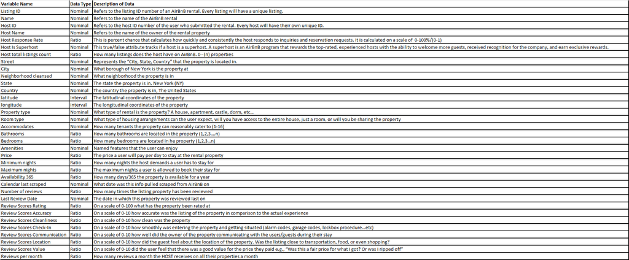

### Data Quality

```python
import pandas as pd
import matplotlib.pyplot as plt
import numpy as np

df = pd.read_csv("NY_Listings.csv", encoding = 'latin-1')
```

### Missing Values

First, we need to examine all missing values in the dataset. Below is a complete run-through of missing values and the techniques used to clean up the dataset.

```python
len(df)
```

```
75749
```

75,749 rows leaves us plenty of wiggle room. Down below, you'll find a summary of null values.

```python
df.isnull().sum()
```

```
Listing ID                         0
Name                              31
Host ID                            0
Host Name                        232
Host Response Rate             45118
Host Is Superhost                  0
Host total listings count        232
Street                         31439
City                               0
Neighbourhood cleansed             0
State                              0
Country                            0
latitude                           0
longitude                          0
Property type                      0
Room type                          0
Accommodates                   31439
Bathrooms                      31581
Bedrooms                       31439
Amenities                      31721
Price                              0
Minimum nights                     0
Maximum nights                 31439
Availability 365                   0
Calendar last scraped          31439
Number of reviews                  0
Last Review Date               16683
Review Scores Rating               0
Review Scores Accuracy             0
Review Scores Cleanliness          0
Review Scores Checkin              0
Review Scores Communication        0
Review Scores Location             0
Review Scores Value                0
Reviews per month                  0
dtype: int64
```

#### Removing unwanted columns

As you can see above, there's a concerning amount of null values. However, some of these columns are not important for our goals. These include Name, Host Name, Calendar last scraped, and Last Review Date. These columns could provide some information, but overall, I'm okay to exclude them from any work we do - especially since the text columns won't give us anything unless we do some language processing.

These columns will be entirely removed from this dataset.

```python
columnsToRemove = ["Name", "Host Name", "Calendar last scraped", "Last Review Date"]

df2 = df.drop(columns = columnsToRemove, axis=1)

df2.isnull().sum()
```

```
Listing ID                         0
Host ID                            0
Host Response Rate             45118
Host Is Superhost                  0
Host total listings count        232
Street                         31439
City                               0
Neighbourhood cleansed             0
State                              0
Country                            0
latitude                           0
longitude                          0
Property type                      0
Room type                          0
Accommodates                   31439
Bathrooms                      31581
Bedrooms                       31439
Amenities                      31721
Price                              0
Minimum nights                     0
Maximum nights                 31439
Availability 365                   0
Number of reviews                  0
Review Scores Rating               0
Review Scores Accuracy             0
Review Scores Cleanliness          0
Review Scores Checkin              0
Review Scores Communication        0
Review Scores Location             0
Review Scores Value                0
Reviews per month                  0
dtype: int64
```

#### Inspecting Rows with Multiple Columns Missing

Here, we've narrowed down the nulls a good amount. Now, lets try removing the rows where Street is null. I have a suspicion that all the columns with 31,439 nulls are missing the same rows. We could try to impute these values, but I fear that columns like Accommodates and Bedrooms are too important to guess on.

```python
df3 = df2[df2['Street'].notnull()]

df3.isnull().sum()
```

```
Listing ID                         0
Host ID                            0
Host Response Rate             13679
Host Is Superhost                  0
Host total listings count        232
Street                             0
City                               0
Neighbourhood cleansed             0
State                              0
Country                            0
latitude                           0
longitude                          0
Property type                      0
Room type                          0
Accommodates                       0
Bathrooms                        142
Bedrooms                           0
Amenities                        282
Price                              0
Minimum nights                     0
Maximum nights                     0
Availability 365                   0
Number of reviews                  0
Review Scores Rating               0
Review Scores Accuracy             0
Review Scores Cleanliness          0
Review Scores Checkin              0
Review Scores Communication        0
Review Scores Location             0
Review Scores Value                0
Reviews per month                  0
dtype: int64
```

```python
len(df3)
```

```
44310
```

Above, we can see that removing Street eliminated many null values. After more investigation, we found that columns with Null Street values were actually empty rows with only zeroes and nulls. While this is simply a hypothesis, these rows may pertain to rentals that were originally listed on Airbnb by their host, but listing was abandoned before the listing was complete.

#### Last four columns

Now that we're down to just four columns to look at, I'll take them one-by-one.

##### Bathrooms

For Bathrooms, these 142 columns only represent .3% of the dataset. I think if we partition out by room type and property type, we can impute the means.

```python
bathroomsIncluded = df3[df3['Bathrooms'].notnull()]
bathroomsMissing = df3[df3['Bathrooms'].isna()]

df4 = df3[["Property type", "Room type", "Bathrooms"]]
df4 = df4[(df4["Property type"].isin(bathroomsMissing["Property type"].unique()))]
df4.groupby(by=["Property type", "Room type"]).mean()
```

| Property type | Room type | Bathrooms |
| --- | --- | --- |
| Apartment | Entire home/apt | 1.099828 |
|  | Private room | 1.096143 |
|  | Shared room | 1.082711 |
| Bed & Breakfast | Entire home/apt | 1.187500 |
|  | Private room | 1.182692 |
|  | Shared room | 1.000000 |
| House | Entire home/apt | 1.646916 |
|  | Private room | 1.195214 |
|  | Shared room | 1.692708 |

```python
# For these values, I feel comfortable assigning 1 to all groups except for House:Entire and House:Shared.
# Those two groups will have 2 imputed.

bathroomsOne = bathroomsMissing[(bathroomsMissing['Property type'].isin(['Apartment', 'Bed & Breakfast'])) |
                                (bathroomsMissing['Property type'] == 'House') &
                                (bathroomsMissing['Room type'] == 'Private room')]

bathroomsTwo = bathroomsMissing[(bathroomsMissing['Property type'] == 'House') &
                               (bathroomsMissing['Room type'] != 'Private room')]


bathroomsOne.loc[:, "Bathrooms"] = 1
bathroomsTwo.loc[:, "Bathrooms"] = 2

df5 = pd.concat([bathroomsIncluded, bathroomsOne, bathroomsTwo], ignore_index=True, axis=0)
```

##### Amenities

```python
df6 = df5[df5['Amenities'].notnull()]
```

#### Host Response Rate

I think this column is fairly important to predicting rating / price. Therefore, we can't just remove these rows. First, we can check for an overlap of hosts with included and missing values. For those that don't match - we will just impute the median.

```python
responseIncluded = df6[df6['Host Response Rate'].notnull()]
responseMissing = df6[df6['Host Response Rate'].isna()]

responseIncluded_small = responseIncluded[["Host ID", "Host Response Rate"]]
responseMissing_small = responseMissing[["Host ID", "Host Response Rate"]]

responseMatches = pd.merge(left = responseIncluded_small, right = responseMissing_small, on="Host ID", how="inner")

responseMatches
```

|  | Host ID | Host Response Rate_x | Host Response Rate_y |
| --- | --- | --- | --- |

```python
responseMissing.loc[:, "Host Response Rate"] = responseIncluded["Host Response Rate"].median()

df7 = pd.concat([responseIncluded, responseMissing], ignore_index=True, axis=0)
```

#### Host total listings count

```python
listingsIncluded = df7[df7['Host total listings count'].notnull()]
listingsMissing = df7[df7['Host total listings count'].isna()]

listingsIncluded_small = listingsIncluded[["Host ID", "Host total listings count"]]
listingsMissing_small = listingsMissing[["Host ID", "Host total listings count"]]

listingsMatches = pd.merge(left = listingsIncluded_small, right = listingsMissing_small, on="Host ID", how="inner")

listingsMatches
```

|  | Host ID | Host total listings count_x | Host total listings count_y |
| --- | --- | --- | --- |

```python
listingsMissing.loc[:, "Host total listings count"] = listingsIncluded["Host total listings count"].median()

df8 = pd.concat([listingsIncluded, listingsMissing], ignore_index=True, axis=0)
```

```python
print("Number of rows: ", str(len(df8)))
df8.isnull().sum()
```

```
Number of rows:  44028
```

```
Listing ID                     0
Host ID                        0
Host Response Rate             0
Host Is Superhost              0
Host total listings count      0
Street                         0
City                           0
Neighbourhood cleansed         0
State                          0
Country                        0
latitude                       0
longitude                      0
Property type                  0
Room type                      0
Accommodates                   0
Bathrooms                      0
Bedrooms                       0
Amenities                      0
Price                          0
Minimum nights                 0
Maximum nights                 0
Availability 365               0
Number of reviews              0
Review Scores Rating           0
Review Scores Accuracy         0
Review Scores Cleanliness      0
Review Scores Checkin          0
Review Scores Communication    0
Review Scores Location         0
Review Scores Value            0
Reviews per month              0
dtype: int64
```

#### Finalizing Null Values

The output above shows that the dataset has no null values anymore and remains at 44,028 rows.

### Outlier Values

To detect outliers, we need to slim down our dataset to columns which would logically have outliers (numerical columns that are not IDs). Then, we need to classify those columns as normal or skewed.

```
array([[<AxesSubplot:title={'center':'Host Response Rate'}>,
        <AxesSubplot:title={'center':'Host total listings count'}>,
        <AxesSubplot:title={'center':'Accommodates'}>,
        <AxesSubplot:title={'center':'Bathrooms'}>],
       [<AxesSubplot:title={'center':'Bedrooms'}>,
        <AxesSubplot:title={'center':'Price'}>,
        <AxesSubplot:title={'center':'Minimum nights'}>,
        <AxesSubplot:title={'center':'Maximum nights'}>],
       [<AxesSubplot:title={'center':'Availability 365'}>,
        <AxesSubplot:title={'center':'Number of reviews'}>,
        <AxesSubplot:title={'center':'Review Scores Rating'}>,
        <AxesSubplot:title={'center':'Review Scores Accuracy'}>],
       [<AxesSubplot:title={'center':'Review Scores Cleanliness'}>,
        <AxesSubplot:title={'center':'Review Scores Checkin'}>,
        <AxesSubplot:title={'center':'Review Scores Communication'}>,
        <AxesSubplot:title={'center':'Review Scores Location'}>],
       [<AxesSubplot:title={'center':'Review Scores Value'}>,
        <AxesSubplot:title={'center':'Reviews per month'}>,
        <AxesSubplot:>, <AxesSubplot:>]], dtype=object)
```

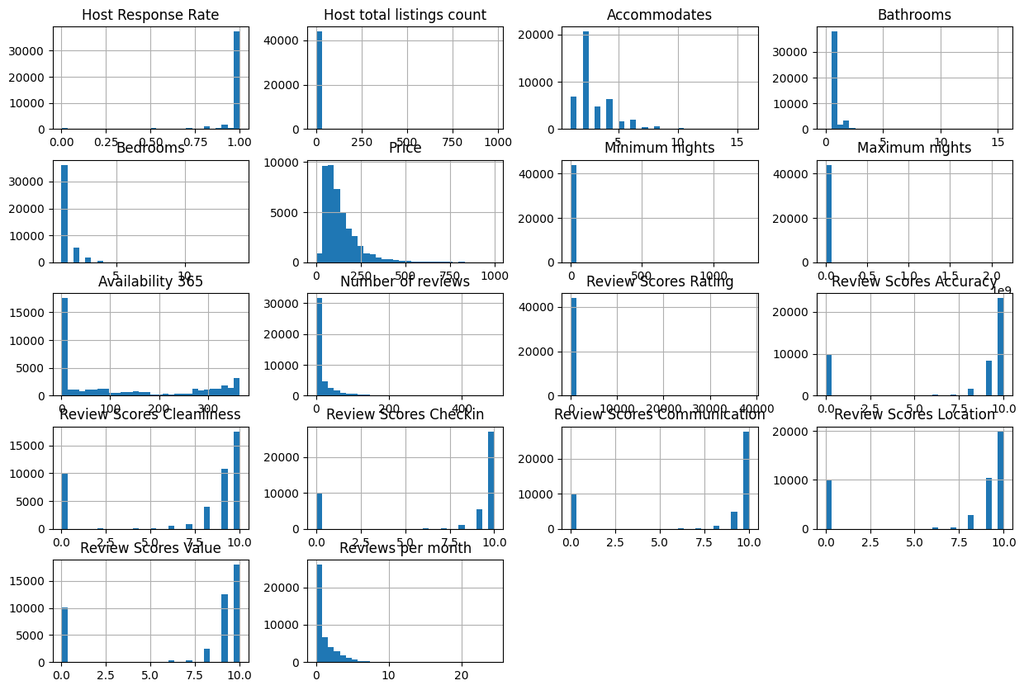

```python
outlier_df = df8[['Host Response Rate','Host total listings count','Accommodates','Bathrooms', 'Bedrooms', 'Price',
            'Minimum nights', 'Maximum nights','Availability 365', 'Number of reviews', 'Review Scores Rating',
            'Review Scores Accuracy', 'Review Scores Cleanliness','Review Scores Checkin', 'Review Scores Communication',
            'Review Scores Location', 'Review Scores Value', 'Reviews per month']]

outlier_df.hist(bins=30, figsize=(15, 10))
```

Looking at the above histograms, we can classify all columns as skewed. Therefore, we will now classify outliers as values outside the range (Q1 - 1.5 * IQR) , (Q3 + 1.5 * IQR).

```python
lower_bounds = []
upper_bounds = []
maximums = []
columns = outlier_df.columns
outlier_count = []

for col in outlier_df.columns:
    Q3 = np.quantile(outlier_df[col], 0.75)
    Q1 = np.quantile(outlier_df[col], 0.25)
    Max = max(outlier_df[col])
    IQR = Q3 - Q1
    lower_range = Q1 - 1.5 * IQR

    if lower_range < 0:
        lower_range = 0

    upper_range = Q3 + 1.5 * IQR

    outliers = len(outlier_df[(outlier_df[col] > upper_range) | (outlier_df[col] < lower_range)])

    lower_bounds.append(lower_range)
    upper_bounds.append(upper_range)
    maximums.append(Max)
    outlier_count.append(outliers)

bounds_df = pd.DataFrame(list(zip(columns, lower_bounds, upper_bounds, maximums, outlier_count)),
                         columns = ["Column","Lower","Upper", "Maximum", "Outlier Count"])

pd.options.display.float_format = '{:.5f}'.format

bounds_df
```

|  | Column | Lower | Upper | Maximum | Outlier Count |
| --- | --- | --- | --- | --- | --- |
| 0 | Host Response Rate | 1.00000 | 1.00000 | 1.00000 | 7008 |
| 1 | Host total listings count | 0.00000 | 3.50000 | 979.00000 | 3964 |
| 2 | Accommodates | 0.00000 | 7.00000 | 16.00000 | 1285 |
| 3 | Bathrooms | 1.00000 | 1.00000 | 15.50000 | 6121 |
| 4 | Bedrooms | 1.00000 | 1.00000 | 14.00000 | 7849 |
| 5 | Price | 0.00000 | 326.50000 | 999.00000 | 2279 |
| 6 | Minimum nights | 0.00000 | 8.50000 | 1250.00000 | 2875 |
| 7 | Maximum nights | 0.00000 | 2769.00000 | 2147483647.00000 | 65 |
| 8 | Availability 365 | 0.00000 | 695.00000 | 365.00000 | 0 |
| 9 | Number of reviews | 0.00000 | 48.50000 | 489.00000 | 5011 |
| 10 | Review Scores Rating | 50.50000 | 126.50000 | 38425.00000 | 10054 |
| 11 | Review Scores Accuracy | 5.00000 | 13.00000 | 10.00000 | 10125 |
| 12 | Review Scores Cleanliness | 2.50000 | 14.50000 | 10.00000 | 10064 |
| 13 | Review Scores Checkin | 5.00000 | 13.00000 | 10.00000 | 10167 |
| 14 | Review Scores Communication | 5.00000 | 13.00000 | 10.00000 | 10062 |
| 15 | Review Scores Location | 5.00000 | 13.00000 | 10.00000 | 10150 |
| 16 | Review Scores Value | 5.00000 | 13.00000 | 10.00000 | 10235 |
| 17 | Reviews per month | 0.00000 | 4.13500 | 24.53000 | 2456 |

#### Column-Specific Outlier Handling

Now we have the lower and upper bounds of our outlier ranges. However, some columns might have outliers - but they're valid data points. Let's take them one by one.

Accommodates: A maximum of 16 is certainly understandale and could very realistically be true. Although some of these rentals that claim to accommodate 16 people are oddly small, that value of 16 still isn't outlandish. Therefore, we'll keep those in.

Bathrooms: Although the maximum of 15.5 is large, that Airbnb has 14 bedrooms. Therefore, it is likely this is just a very large rental.

Price: Logically, a maximum of $999 makes sense. And since we don't quite have a way to validate or invalidate these prices, we will leave them in.

Minimum nights: The ~3000 rows with a minimum nights value over 8.5 is quite daunting. It is likely that some of the higher values (above 50) are mistakes, as Airbnbs with a minimum night stay of 50 nights is unheard of. Therefore, we will cap the maximum value for this column at 10.

Maximum nights: Similar to minimum nights, it is very likely that these higher values are mistakes. Since Airbnbs do allow very long stays, we will cap the maximum at 365.

Availability 365: The logical maximum for this column is 365. This is the maximum for this column, so these values are valid.

Number of reviews: The upper bound here of ~50 reviews is fairly low. In fact, the maximum of 489 reviews isn't outlandish either. Therefore, we can't classify any of these values as mistakes, so these values will remain.

Review Scores Accuracy - Review Scores Value: The maximum here (according to the data dictionary) is 10. Therefore, these columns are valid.

Reviews per month: While the maximum of 24.53 is impressive, it cannot be ruled out. Therefore, we will keep those values.

```python
# Host Response Rate

# The logical maximum for this value is 1. However, the "outlier" values are actually 1.0, as seen below.
# Therefore, there are no valid outliers in this column.

temp_df = df8[df8['Host Response Rate'] >= 1]

temp_df['Host Response Rate'].value_counts()
```

```
1.00000    37020
Name: Host Response Rate, dtype: int64
```

```python
# Host total listings count

# Here, we can see that there are values in the 100's. However, we do not know if some of these listings being counted are
# owned by this host in other areas. Therefore, this column is difficult to separate into outlier status.

temp_df = df8[df8['Host total listings count'] > 3.50000]

temp_df['Host total listings count'].unique()
```

```
array([  4.,  16.,   5.,   6.,  14.,  12.,   8.,   7., 149.,  15.,  10.,
         9.,  11.,  22.,  47.,  13.,  28.,  17.,  23.,  19.,  20.,  31.,
       296., 236.,  24.,  33.,  64., 113.,  39.,  54.,  42.,  94., 218.,
        27., 648.,  18.,  38.,  56.,  49., 316., 979.,  35., 248.,  25.,
       258.,  36.,  21.,  83.,  52., 159.,  85.,  41.])
```

```python
# Review Scores Rating

# The maximum here (according to the data dictionary) is 100. Those that are above this threshold are wildy so, having
# three occurrences of 38,425. These are likely mistakes, so these rows will be removed.

temp_df = df8[df8['Review Scores Rating'] > 100]

temp_df['Review Scores Rating'].value_counts()
```

```
38425    3
Name: Review Scores Rating, dtype: int64
```

From the research above, we came away with a few transformations to make: 1. Cap minimum nights at 10. 2. Cap maximum nights at 365. 3. Remove three rows with review scores rating above 100

```python
df8.clip(upper=pd.Series({'Minimum nights': 10, 'Maximum nights': 365}), axis=1)
print(df8.shape)
df9 = df8[df8['Review Scores Rating'] <= 100]
print(df9.shape)
```

```
(44028, 31)
(44025, 31)
```

### Duplicate Values

Almost all of the columns in this dataset would logically have duplicate values (same number of bathrooms, reviews, etc.). The only column that should not have any duplicate values is Listing ID. Therefore, we will compare the length of the dataset with the amount of unique Listing IDs.

```python
print("Number of observations: ", str(len(df9)))
print("Number of unique Listing ID's: ", str(len(df9['Listing ID'].unique())))
```

```
Number of observations:  44025
Number of unique Listing ID's:  44025
```

Since the number of unique Listing ID's is equal to the number of rows, we can be confident that there are no duplicate listings in the dataset.

### Df.info()

```python
df = df9
df.info()
```

```
<class 'pandas.core.frame.DataFrame'>
Int64Index: 44025 entries, 0 to 44027
Data columns (total 31 columns):
 #   Column                       Non-Null Count  Dtype
---  ------                       --------------  -----
 0   Listing ID                   44025 non-null  int64
 1   Host ID                      44025 non-null  int64
 2   Host Response Rate           44025 non-null  float64
 3   Host Is Superhost            44025 non-null  bool
 4   Host total listings count    44025 non-null  float64
 5   Street                       44025 non-null  object
 6   City                         44025 non-null  object
 7   Neighbourhood cleansed       44025 non-null  object
 8   State                        44025 non-null  object
 9   Country                      44025 non-null  object
```

[output cut: 23 more lines]

According to the df.info output above, each column is the same length and all types are correct. Some types may be changed later on to better fit the purpose of the code, but for now, the data looks good.

### Data Understanding 2

*Visualize the any important attributes appropriately. Important: Provide an interpretation for any charts or graphs.*

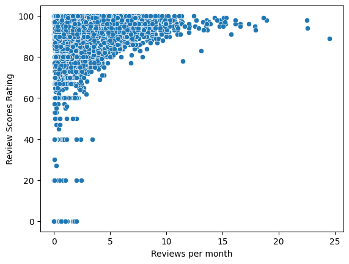

```python
import seaborn as sns

sns.scatterplot(data = df.reset_index(), x='Reviews per month', y='Review Scores Rating');
```

The above chart shows that the vast majority of listings have a rating above 60, but as rating increases, the amount of reviews per month increases as well.

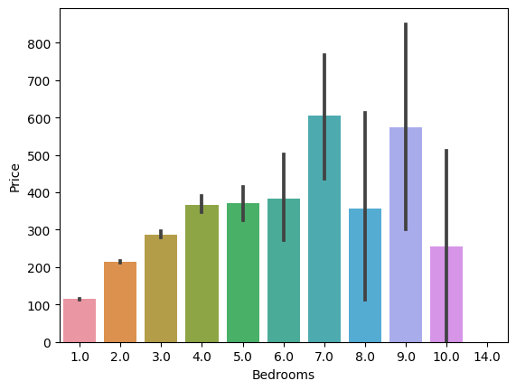

```python
sns.barplot(data = df.reset_index(), x = 'Bedrooms', y='Price');
```

The bar plot shows that as the number of bedrooms increases so does price up to a point. Once 7 bedrooms is reached price begins to behave somewhat erradically.

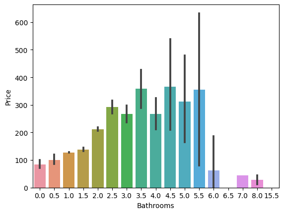

```python
sns.barplot(data = df.reset_index(), x = 'Bathrooms', y='Price');
```

### Modeling and Evaluation 1

###### determine viable candidates for clustering

lets first look at some of the relationships using common sense. Bathrooms and bedrooms would viable candidates All of the 'review scores...' fields Host response rate and host total listings count

###### Train and adjust parameters

```python
def categorise(row):
    if row['Review Scores Rating'] > 89:
        return 1
    else:
        return 0
    return 'IDK'

df['Grade'] = df.apply(lambda row: categorise(row), axis=1)

df['Grade'].value_counts(normalize=True)
```

```
1   0.62667
0   0.37333
Name: Grade, dtype: float64
```

```python
data = df[['Host Response Rate', 'Host Is Superhost', 'Host total listings count', 'City', 'Room type',
          'Accommodates', 'Bathrooms', 'Bedrooms', 'Price', 'Minimum nights', 'Maximum nights', 'Availability 365',
          'Number of reviews', 'Reviews per month', 'Grade']]
```

```python
# One-hot Encode
city_one_hot = pd.get_dummies(data['City'])
room_one_hot = pd.get_dummies(data['Room type'])

data = data.drop('City',axis = 1)
data = data.drop('Room type',axis = 1)

data = data.join(city_one_hot)
data = data.join(room_one_hot)


# Map boolean to integer
data["Host Is Superhost"] = data["Host Is Superhost"].astype(int)
```

```python
# Scale Data
from sklearn.preprocessing import MinMaxScaler
scaler = MinMaxScaler()

grade = data['Grade']
to_scale = data.drop("Grade", axis = 1)
cols = to_scale.columns

scaled = scaler.fit_transform(to_scale)

data = pd.DataFrame(scaled, columns = cols)
data['Grade'] = grade
```

```python
data2 = data.dropna()

stats_df = pd.DataFrame()
```

```python
# use random forest to create a baseline
from sklearn.model_selection import StratifiedKFold, cross_val_score
from sklearn.ensemble import RandomForestClassifier

y = data2['Grade']
X = data2.drop('Grade', axis=1)
cv = StratifiedKFold(n_splits=5)

clf = RandomForestClassifier(n_estimators = 150, random_state = 1)

acc = cross_val_score(clf, X, y=y, cv = cv)

print("Average accuracy = ", acc.mean()*100, "+-", acc.std()*100)

temp_acc = round(acc.mean()*100,2)
temp_std = round(acc.std()*100,2)
temp_lwr = temp_acc - temp_std
temp_upr = temp_acc + temp_std

temp_df = pd.DataFrame(data = {'Category':['Random Forest'], 'Param 1':['None'], 'Param 2':['None'], 'Acc':[temp_acc], 'Std':[temp_std], 'Lwr':[temp_lwr], 'Upr':[temp_upr]})
stats_df = pd.concat([stats_df, temp_df])

# code addapted from https://nbviewer.org/github/jakemdrew/DataMiningNotebooks/blob/master/09.%20Clustering%20and%20Discretization.ipynb
```

```
Average accuracy =  53.22728892266977 +- 13.08807924572327
```

```python
stats_df
```

|  | Category | Param 1 | Param 2 | Acc | Std | Lwr | Upr |
| --- | --- | --- | --- | --- | --- | --- | --- |
| 0 | Random Forest | None | None | 53.23000 | 13.09000 | 40.14000 | 66.32000 |

```python
# k means clustering on bathrooms and bedrooms
from sklearn.cluster import KMeans
import numpy as np
import pandas as pd

X1 = data2[['Bathrooms','Bedrooms']]

cls = KMeans(n_clusters=8, init='k-means++',random_state=1)
cls.fit(X1)
newfeature = cls.labels_ # the labels from kmeans clustering

y = data2['Grade']
X = data2.drop(['Grade', 'Bathrooms', 'Bedrooms'], axis=1)

X = np.column_stack((X,pd.get_dummies(newfeature)))

acc = cross_val_score(clf,X,y=y,cv=cv)

print ("Average accuracy (with kmeans for class/fare)= ", acc.mean()*100, "+-", acc.std()*100)

temp_acc = round(acc.mean()*100,2)
temp_std = round(acc.std()*100,2)
temp_lwr = temp_acc - temp_std
temp_upr = temp_acc + temp_std

temp_df = pd.DataFrame(data = {'Category':['KMeans'], 'Param 1':['Clusters:8'], 'Param 2':['None'], 'Acc':[temp_acc], 'Std':[temp_std], 'Lwr':[temp_lwr], 'Upr':[temp_upr]})
#stats_df = pd.concat([stats_df, temp_df])

# code addapted from https://nbviewer.org/github/jakemdrew/DataMiningNotebooks/blob/master/09.%20Clustering%20and%20Discretization.ipynb
```

```
Average accuracy (with kmeans for class/fare)=  53.309065287292626 +- 13.0836539380655
```

```python
stats_df
```

|  | Category | Param 1 | Param 2 | Acc | Std | Lwr | Upr |
| --- | --- | --- | --- | --- | --- | --- | --- |
| 0 | Random Forest | None | None | 53.23000 | 13.09000 | 40.14000 | 66.32000 |

```python
# try a range of clustering variables
# the maximum number of unique bedroom counts is 11. We will set this as our max
params = []
for n_bb in range(1,11):

    # append on the clustering
    X1 = data2[['Bathrooms','Bedrooms']]

    cls = KMeans(n_clusters=n_bb, init='k-means++',random_state=1)
    cls.fit(X1)
    newfeature = cls.labels_ # the labels from kmeans clustering

    y = data2['Grade']
    X = data2.drop(['Grade', 'Bathrooms', 'Bedrooms'], axis=1)

    X = np.column_stack((X,pd.get_dummies(newfeature)))

    acc = cross_val_score(clf,X,y=y,cv=cv)

    print ("Average accuracy (with kmeans for class/fare)= ", acc.mean()*100, "+-", acc.std()*100)

    temp_acc = round(acc.mean()*100,2)
    temp_std = round(acc.std()*100, 2)
    temp_lwr = temp_acc - temp_std
    temp_upr = temp_acc + temp_std
    temp_label = 'KMeans'

    temp_df = pd.DataFrame(data = {'Category':[temp_label], 'Param 1': ['Clusters:'+str(n_bb)], 'Param 2': ['None'], 'Acc':[temp_acc], 'Std':[temp_std], 'Lwr':[temp_lwr], 'Upr':[temp_upr]})
    stats_df = pd.concat([stats_df, temp_df])
    print(n_bb)

# code addapted from https://nbviewer.org/github/jakemdrew/DataMiningNotebooks/blob/master/09.%20Clustering%20and%20Discretization.ipynb
```

```
Average accuracy (with kmeans for class/fare)=  53.04556650595813 +- 12.885625684442775
1
Average accuracy (with kmeans for class/fare)=  53.111451327812645 +- 12.735352140059092
2
Average accuracy (with kmeans for class/fare)=  53.19321814641581 +- 12.999250070098507
3
Average accuracy (with kmeans for class/fare)=  53.261358666921566 +- 13.147788185097614
4
Average accuracy (with kmeans for class/fare)=  53.25227524219155 +- 13.050037292508687
5
Average accuracy (with kmeans for class/fare)=  53.24773752883478 +- 13.01508608751725
6
Average accuracy (with kmeans for class/fare)=  53.213659270565415 +- 13.089902960456385
7
Average accuracy (with kmeans for class/fare)=  53.309065287292626 +- 13.0836539380655
8
Average accuracy (with kmeans for class/fare)=  53.13643093932059 +- 12.960991670239789
9
Average accuracy (with kmeans for class/fare)=  53.27272230035338 +- 13.084346728539616
10
```

```python
stats_df
```

|  | Category | Param 1 | Param 2 | Acc | Std | Lwr | Upr |
| --- | --- | --- | --- | --- | --- | --- | --- |
| 0 | Random Forest | None | None | 53.23000 | 13.09000 | 40.14000 | 66.32000 |
| 0 | KMeans | Clusters:1 | None | 53.05000 | 12.89000 | 40.16000 | 65.94000 |
| 0 | KMeans | Clusters:2 | None | 53.11000 | 12.74000 | 40.37000 | 65.85000 |
| 0 | KMeans | Clusters:3 | None | 53.19000 | 13.00000 | 40.19000 | 66.19000 |
| 0 | KMeans | Clusters:4 | None | 53.26000 | 13.15000 | 40.11000 | 66.41000 |
| 0 | KMeans | Clusters:5 | None | 53.25000 | 13.05000 | 40.20000 | 66.30000 |
| 0 | KMeans | Clusters:6 | None | 53.25000 | 13.02000 | 40.23000 | 66.27000 |
| 0 | KMeans | Clusters:7 | None | 53.21000 | 13.09000 | 40.12000 | 66.30000 |
| 0 | KMeans | Clusters:8 | None | 53.31000 | 13.08000 | 40.23000 | 66.39000 |
| 0 | KMeans | Clusters:9 | None | 53.14000 | 12.96000 | 40.18000 | 66.10000 |
| 0 | KMeans | Clusters:10 | None | 53.27000 | 13.08000 | 40.19000 | 66.35000 |

```python
# try with Agglomerative Clustering
from sklearn.cluster import AgglomerativeClustering

X1 = data2[['Bathrooms','Bedrooms']]

params = []
for link in ['ward', 'complete', 'average']:
    for n_bb in range(5,6):

        # append on the clustering
        cls_bb = AgglomerativeClustering(n_clusters=n_bb, linkage=link)
        cls_bb.fit(X1)
        newfeature_bb = cls_bb.labels_ # the labels from kmeans clustering

        y = data2['Grade']
        X = data2.drop(['Grade', 'Bathrooms', 'Bedrooms'], axis=1)
        X = np.column_stack((X,pd.get_dummies(newfeature_bb)))

        acc = cross_val_score(clf,X,y=y,cv=cv)
        params.append((n_bb,acc.mean()*100,acc.std()*100)) # save state


        print ("C=",n_bb,link,"Average accuracy = ", acc.mean()*100, "+-", acc.std()*100)

        temp_acc = round(acc.mean()*100,2)
        temp_lwr = temp_acc - round(acc.std()*100,2)
        temp_upr = temp_acc + round(acc.std()*100,2)

        temp_df = pd.DataFrame(data = {'Category':['Agglomerative'], 'Param 1':['Link:'+str(link)], 'Param 2':['Clusters:'+str(n_bb)], 'Acc':[temp_acc], 'Lwr':[temp_lwr], 'Upr':[temp_upr]})
        stats_df = pd.concat([stats_df, temp_df])
        print(temp_label)

# code addapted from https://nbviewer.org/github/jakemdrew/DataMiningNotebooks/blob/master/09.%20Clustering%20and%20Discretization.ipynb
```

```
C= 5 ward Average accuracy =  53.227296146684665 +- 12.882550664021549
KMeans
C= 5 complete Average accuracy =  53.250016705534456 +- 12.884692755894239
KMeans
C= 5 average Average accuracy =  53.33860299419937 +- 12.996404831081707
KMeans
```

```python
# DBSCAN

from sklearn.cluster import DBSCAN

params = []
for eps in [0.1, 0.125, 0.15]:
    for mpts in range(5,6):

        # append on the clustering
        cls_bb = DBSCAN(eps=eps, min_samples=mpts)
        cls_bb.fit(X1)
        newfeature_bb = cls_bb.labels_ # the labels from kmeans clustering

        y = data2['Grade']
        X = data2.drop(['Grade', 'Bathrooms', 'Bedrooms'], axis=1)
        X = np.column_stack((X,pd.get_dummies(newfeature_bb)))

        acc = cross_val_score(clf,X,y=y,cv=cv)
        params.append((n_bb,acc.mean()*100,acc.std()*100)) # save state

        print (eps,mpts,"Average accuracy = ", acc.mean()*100, "+-", acc.std()*100)

        temp_acc = round(acc.mean()*100,2)
        temp_lwr = temp_acc - round(acc.std()*100,2)
        temp_upr = temp_acc + round(acc.std()*100,2)

        temp_df = pd.DataFrame(data = {'Category':['DBSCAN'], 'Param 1':['Eps:'+str(eps)], 'Param 2':['MinPts:'+str(mpts)], 'Acc':[temp_acc], 'Lwr':[temp_lwr], 'Upr':[temp_upr]})
        stats_df = pd.concat([stats_df, temp_df])

# code addapted from https://nbviewer.org/github/jakemdrew/DataMiningNotebooks/blob/master/09.%20Clustering%20and%20Discretization.ipynb
```

```
0.1 5 Average accuracy =  53.463546975833864 +- 12.927684929476538
0.125 5 Average accuracy =  53.463546975833864 +- 12.927684929476538
0.15 5 Average accuracy =  53.28862493714461 +- 13.00164892608294
```

### Modeling and Evaluation 2

Evaluate and Compare

```python
stats_df
```

|  | Category | Param 1 | Param 2 | Acc | Std | Lwr | Upr |
| --- | --- | --- | --- | --- | --- | --- | --- |
| 0 | Random Forest | None | None | 53.23000 | 13.09000 | 40.14000 | 66.32000 |
| 0 | KMeans | Clusters:1 | None | 53.05000 | 12.89000 | 40.16000 | 65.94000 |
| 0 | KMeans | Clusters:2 | None | 53.11000 | 12.74000 | 40.37000 | 65.85000 |
| 0 | KMeans | Clusters:3 | None | 53.19000 | 13.00000 | 40.19000 | 66.19000 |
| 0 | KMeans | Clusters:4 | None | 53.26000 | 13.15000 | 40.11000 | 66.41000 |
| 0 | KMeans | Clusters:5 | None | 53.25000 | 13.05000 | 40.20000 | 66.30000 |
| 0 | KMeans | Clusters:6 | None | 53.25000 | 13.02000 | 40.23000 | 66.27000 |
| 0 | KMeans | Clusters:7 | None | 53.21000 | 13.09000 | 40.12000 | 66.30000 |
| 0 | KMeans | Clusters:8 | None | 53.31000 | 13.08000 | 40.23000 | 66.39000 |
| 0 | KMeans | Clusters:9 | None | 53.14000 | 12.96000 | 40.18000 | 66.10000 |
| 0 | KMeans | Clusters:10 | None | 53.27000 | 13.08000 | 40.19000 | 66.35000 |
| 0 | Agglomerative | Link:ward | Clusters:5 | 53.23000 | NaN | 40.35000 | 66.11000 |
| 0 | Agglomerative | Link:complete | Clusters:5 | 53.25000 | NaN | 40.37000 | 66.13000 |
| 0 | Agglomerative | Link:average | Clusters:5 | 53.34000 | NaN | 40.34000 | 66.34000 |
| 0 | DBSCAN | Eps:0.1 | MinPts:5 | 53.46000 | NaN | 40.53000 | 66.39000 |
| 0 | DBSCAN | Eps:0.125 | MinPts:5 | 53.46000 | NaN | 40.53000 | 66.39000 |
| 0 | DBSCAN | Eps:0.15 | MinPts:5 | 53.29000 | NaN | 40.29000 | 66.29000 |

Between KMeans, Agglomerative, and DBSCAN methods, performance is relatively stable at just over 50% accuracy. Therefore, this should open up the debate if clustering is worth the effort for this problem, especially considering that the random forest performs just as well.

KMeans is more useful in the sense that it doesn't consume too much time or memory - but it doesn't perform at any better rate than the other options.

In terms of cost, Agglo. and DBSCAN are much more computational expensive, leading to long training times and large required amounts of memory. While a company such as AirBnb should not have an issue running these models, this can become a hurdle for other populations, such as students or data scientists at a company that hasn't invested much into this field.

### Modeling and Evaluation 3

Visualize Results

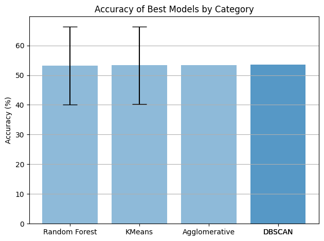

```python
# Take best performing model from each category

kmeans = stats_df[stats_df['Category'] == 'KMeans']
best_kmeans = kmeans[kmeans['Acc'] == kmeans['Acc'].max()]
agglo = stats_df[stats_df['Category'] == 'Agglomerative']
best_agglo = agglo[agglo['Acc'] == agglo['Acc'].max()]
dbscan = stats_df[stats_df['Category'] == 'DBSCAN']
best_dbscan = dbscan[dbscan['Acc'] == dbscan['Acc'].max()]

best_models = stats_df[stats_df['Category'] == 'Random Forest']
best_models = pd.concat([best_models, best_kmeans, best_agglo, best_dbscan])

fig, ax = plt.subplots()
ax.bar(best_models['Category'], best_models['Acc'], yerr=best_models['Std'], align='center', alpha=0.5, ecolor='black', capsize=10)
ax.set_ylabel('Accuracy (%)')
ax.set_xticks(best_models['Category'])
ax.set_title('Accuracy of Best Models by Category')
ax.yaxis.grid(True)

# Save the figure and show
plt.tight_layout()
plt.show()
```

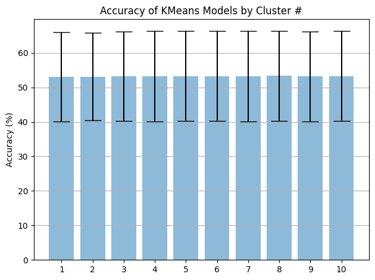

```python
kmeans[['Nan', 'Clusters']] = kmeans['Param 1'].str.split(':', expand=True)

fig, ax = plt.subplots()
ax.bar(kmeans['Clusters'], kmeans['Acc'], yerr=kmeans['Std'], align='center', alpha=0.5, ecolor='black', capsize=10)
ax.set_ylabel('Accuracy (%)')
ax.set_xticks(kmeans['Clusters'])
ax.set_title('Accuracy of KMeans Models by Cluster #')
ax.yaxis.grid(True)

plt.tight_layout()
plt.show()
```

```python
agglo
```

|  | Category | Param 1 | Param 2 | Acc | Std | Lwr | Upr |
| --- | --- | --- | --- | --- | --- | --- | --- |
| 0 | Agglomerative | Link:ward | Clusters:5 | 53.23000 | NaN | 40.35000 | 66.11000 |
| 0 | Agglomerative | Link:complete | Clusters:5 | 53.25000 | NaN | 40.37000 | 66.13000 |
| 0 | Agglomerative | Link:average | Clusters:5 | 53.34000 | NaN | 40.34000 | 66.34000 |

```python
dbscan
```

|  | Category | Param 1 | Param 2 | Acc | Std | Lwr | Upr |
| --- | --- | --- | --- | --- | --- | --- | --- |
| 0 | DBSCAN | Eps:0.1 | MinPts:5 | 53.46000 | NaN | 40.53000 | 66.39000 |
| 0 | DBSCAN | Eps:0.125 | MinPts:5 | 53.46000 | NaN | 40.53000 | 66.39000 |
| 0 | DBSCAN | Eps:0.15 | MinPts:5 | 53.29000 | NaN | 40.29000 | 66.29000 |

The charts and tables above enforce the same conclusion as the previous section - no specific algorithm or parameter selection improves clustering performance significantly.

### Modeling and Evaluation 4

The accuracy not being as high was a large area of concern for our group. Unfortunately we did not receive an accuracy % as high as we would like.

#### K-Means

K-Means is typically used to compress complex and larger datasets into partionaed clusters that are simpler. K-Means is using the distance between points

Pros:

-Simple to use, junior data scientists could use these models well

-Easiest to interpret

-For larger datasets like ours, we can create a lot of clusters

Cons:

-If we were to run this model several times, we run the risk of getting different results. K-Means lacks consistency

-Predicting the number to use for the k value is difficult

#### Agglomerative

We used this by using linkage distance to merge the pairs of sample data.

Pros:

-The output is the easiest to interpret. Hirearchical clustering is very simple and sleek.

-The dendrogram that we receive from an output gives us a relatively good starting point of how many numbers of classes we can group into

Cons: -Cost. Compute costs primarily. -Extreme sensitivity to outliers -Time complexity

#### DB Scan

We use DBscan to calculate the number of data points within each cluster

Pros: -No need to specify the number of clusters beforehand -Outliers are not an issue

Cons: -Differing densities can throw the model off -Choosing an eps value is not simple -The algorithim starts within a random point so border points are not as easily defined

# Deployment

## Did we achieve our goals

Unfortunately not. The accuracy did not improve significantly. We wanted to give Airbnb a tool to categorize their listings in an almost definite way. Unfortunately we were not able to accurately cluster the listings in a way that would prove to be a net add to Airbnb's business.

## If not, can we reign in the utility of our modeling

In a way, this is the intended utility. As a group we realized that clustering might not be the most pertinent issue that Airbnb could seek to gain advantage from. This still serves to be useful as knowing a direction to not head down is a lot better than not having any direction at all.

## How useful is our modeling for interested parties, and how we would deploy

The models that we have used above give us a roadmap that would allow AirBnb to split their listings into easily categorized groupings. If depoloyed, this model would introduce a feature when it came to listing and locating properties where users on the listing side could tag the features they either want selected or can offer.

From a user perspective: Users benefit from the models we have put in place by getting a better experience when it comes to booking rentals. When selecting properties users would be able to select some pictures of features that they would want for their rental property. Examples that come to mind could be "spacious living room, lofted ceilings, garage style parking". The examples for this continue, but with this data and the models used, I think the users would greatly benefit from this.

## What other data should be collected

One other big data point I think we should capture is how often listings are actually being used (the % of listings that are being used/the total amount of listings available). New York for example often has weekends where more people are staying in rental properties (Fashion Week, Tennis' US Open, NYC marathon, Super Bowl, etc..). Weekends like this are bound to capture more out of towners seeking temporary housing accomodations. Having an increase in demand will allow listers of properties to be able to charge more money for their listings.

## How often would we need to update our model

Paying attention to real estate is always a very active endeavor. With the nature of real estate being what it is, I feel that our data would need to be updated daily. New listings tend to pop up on Airbnb daily and it is important to note what prices those new properties are being rented out at. Updating the data daily will also allow Airbnb to have a more accurate handle on the demand surges. Having a accurate pricing point during these demand increases will allow the lister to feel that they are not losing out on potential money.

### Exceptional Work

You have free reign to provide additional analyses or combine analyses.

In order to see if any improvements can be made a few more clustering algorithms will be used. Mean shift clustering and BIRCH will be used. Mean shift clustering should make our clusters more robust to outliers and will not require us to input a number of clusters to run. BIRCH is an algorithm that performs well on large datasets. Something that our previous algorithms had issues with considering the size of our data.

```python
# mean shift clustering
from numpy import unique
from numpy import where
from sklearn.datasets import make_classification
from sklearn.cluster import MeanShift
from matplotlib import pyplot


X1 = data2[['Bathrooms','Bedrooms']]

# append on the clustering
cls_birch = MeanShift()
cls_birch.fit(X1)
newfeature_bb = cls_birch.labels_ # the labels from kmeans clustering

y = data2['Grade']
X = data2.drop(['Grade', 'Bathrooms', 'Bedrooms'], axis=1)
X = np.column_stack((X,pd.get_dummies(newfeature_bb)))

acc = cross_val_score(clf,X,y=y,cv=cv)
params.append((n_bb,acc.mean()*100,acc.std()*100)) # save state

print ("Average accuracy = ", acc.mean()*100, "+-", acc.std()*100)

# code addapted from https://nbviewer.org/github/jakemdrew/DataMiningNotebooks/blob/master/09.%20Clustering%20and%20Discretization.ipynb
```

```
Average accuracy =  53.49535715142645 +- 12.7715978733942
```

```python
# BIRCH clustering

from numpy import unique
from numpy import where
from sklearn.datasets import make_classification
from sklearn.cluster import Birch
from matplotlib import pyplot

X1 = data2[['Bathrooms','Bedrooms']]

# append on the clustering
cls_birch = Birch(threshold=0.01, n_clusters=2)
cls_birch.fit(X1)
newfeature_bb = cls_birch.labels_ # the labels from kmeans clustering

y = data2['Grade']
X = data2.drop(['Grade', 'Bathrooms', 'Bedrooms'], axis=1)
X = np.column_stack((X,pd.get_dummies(newfeature_bb)))

acc = cross_val_score(clf,X,y=y,cv=cv)
params.append((n_bb,acc.mean()*100,acc.std()*100)) # save state

print ("Average accuracy = ", acc.mean()*100, "+-", acc.std()*100)

# code addapted from https://nbviewer.org/github/jakemdrew/DataMiningNotebooks/blob/master/09.%20Clustering%20and%20Discretization.ipynb
```

```
Average accuracy =  53.25001980154084 +- 12.740341447106918
```

From the results we can see that there is little to no improvement over the other algorithms.